# CBASS 2020: Thermal tolerance of *A. cervicornis* across 6 Florida coral nurseries

Ross Cunning

05 April, 2021

```r
# Import cleaned datasets from each nursery
clean_data_files <- list.files(path = "data/processed",
                               pattern = "*_clean.csv",
                               full.names = TRUE)
clean_data <- clean_data_files %>% map_dfr(read_csv)

# Import genotype metadata
gmd <- read_csv("data/genotype_metadata_raw.csv") %>%
  mutate(nursery = tolower(nursery),
         across(everything(), str_squish),
         across(ends_with("lat"), ~signif(parse_lat(.), 6)),             # parse latitude
         across(ends_with("lon"), ~signif(parse_lon(.), 6))) %>%        # parse longitude
  mutate(ugeno = gsub(" ", "", ugeno)) %>%
  select(nursery, name = geno, source_lat, source_lon, MMM_5km)

# Import names key
gkey <- read_csv("data/genotype_name_key.csv") %>%
  mutate(alt0 = geno) %>%
  pivot_longer(starts_with("alt"), names_to = "alt", values_to = "name") %>%
  drop_na() %>%
  select(geno, name)

# Combine cleaned data with genotype metadata
df.all <- clean_data %>%
  rename(name = geno) %>%
  left_join(gkey) %>%
  select(nursery, geno, name, max_temp, fvfm, date) %>%
  left_join(gmd) %>%
  # Order nurseries from south to north
  mutate(nursery = factor(nursery, levels = c("mote", "fwc", "rrt", "crf", "um", "nsu"))) %>%
  select(nursery, name, geno, date, max_temp, fvfm, source_lat, source_lon, MMM_5km)

# Define dose-response curves using same constraints
ll3 <- function(data) {
  drm(fvfm ~ max_temp, data = data,
      fct = LL.3(names = c("hill", "max", "ED50")),
      upperl = c(120, 0.72, 40),
      lowerl = c(10, 0.55, 30))}

# Fit model to each coral, get parameters, fitted values, and residuals
mods <- df.all %>%
  nest(data = c(max_temp, fvfm)) %>%
  # Fit the model to each coral
  mutate(ll3 = map(data, ll3)) %>%
  # Get model parameters and fitted values/residuals
  mutate(pars = map(ll3, tidy),
         pred = map2(ll3, data, ~augment(.x, drop_na(.y, fvfm))))

# Extract parameter values from model fits
res.all <- mods %>%
  unnest(pars) %>%
  pivot_wider(names_from = term,
              values_from = c(estimate, std.error, statistic, p.value)) %>%
  clean_names() %>%
  select(!where(is.list), -curve)

# Filter to analyze only CBASS runs from Coral Reef II in August and October
res <- res.all %>%
  filter(date %in% c("2020-08", "2020-10"))
```

# How many corals and unique genotypes were tested?

```r
res %>%
  summarize(ncoral = n_distinct(nursery, name),
            ngeno = n_distinct(geno)) %>%
  knitr::kable()
```

| ncoral | ngeno |
| --- | --- |
| 228 | 176 |

# What is the range in thermal tolerance across all genotypes?

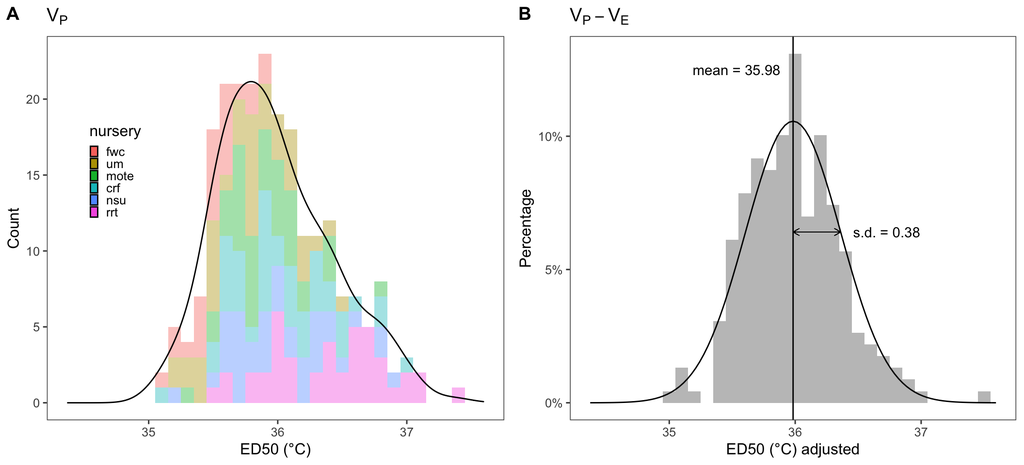

```r
# Basic histogram
# ggplot(res, aes(x = estimate_ed50)) +
#   geom_histogram(binwidth = 0.1) +
#   labs(x = "ED50 Tolerance (°C)", y = "Number of genotypes",
#        title = "Histogram of ED50 values for all corals") +
#   theme_few()

# Histogram colored by nursery with density plot
hist1 <- res %>%
  mutate(nursery = factor(nursery, levels = c("fwc", "um", "mote", "crf", "nsu", "rrt"))) %>%
  ggplot(aes(x = estimate_ed50)) +
  geom_histogram(aes(fill = nursery), binwidth = 0.1, alpha = 0.4) +
  geom_density(aes(y = ..count.. * 0.1)) +
  theme_few() +
  theme(legend.position = c(0.15, 0.65), legend.key.size = unit(0.25, "cm")) +
  labs(x = "ED50 (°C)", y = "Count", title = expression(V[P]))

# Remove nursery effect
mod <- lm(estimate_ed50 ~ nursery, data = res)
res.adj <- augment(mod, data = res) %>%
  mutate(ed50_adj = mean(res$estimate_ed50) + .resid)

# Get mean and sd from adjusted distribution
meanadj <- mean(res.adj$ed50_adj)
sdadj <- sd(res.adj$ed50_adj)

hist2 <- ggplot(res.adj, aes(x = ed50_adj)) +
  geom_histogram(aes(y = ..count../sum(..count..)), binwidth = 0.1, alpha = 0.4) +
  stat_function(fun = ~ dnorm(.x, meanadj, sdadj) * 0.1) +
  geom_vline(aes(xintercept = meanadj)) +
  geom_segment(aes(x = meanadj, xend = meanadj + sdadj,
                   y = dnorm(meanadj + sdadj, meanadj, sdadj) * 0.1,
                   yend = dnorm(meanadj + sdadj, meanadj, sdadj) * 0.1),
               arrow = arrow(length = unit(0.2,"cm"), ends = "both"), lwd = 0.1) +
  xlim(qnorm(c(0.00001, 0.99999), meanadj, sdadj)) +
  scale_y_continuous(labels = scales::percent_format(accuracy = 1)) +
  annotate("text", x = meanadj - 0.1, y = 0.125, adj = 1,
           label = paste0("mean = ", round(meanadj, 2))) +
  annotate("text", x = meanadj + sdadj + 0.1,
           y = dnorm(meanadj + sdadj, meanadj, sdadj) * 0.1,
           adj = 0, label = paste0("s.d. = ", round(sdadj, 2))) +
  theme_few() +
  labs(x = "ED50 (°C) adjusted", y = "Percentage", title = expression(V[P] - V[E]))


# Combine histograms into multi-panel figure
fig2 <- cowplot::plot_grid(
  hist1 + xlim(qnorm(c(0.00001, 0.99999), meanadj, sdadj)),
  hist2, labels = "AUTO")
fig2
```

```r
# Summarize original distribution
tidy(summary(res$estimate_ed50)) %>%
  knitr::kable(caption = "Summary of unadjusted ED50 values")
```

Summary of unadjusted ED50 values

| minimum | q1 | median | mean | q3 | maximum |
| --- | --- | --- | --- | --- | --- |
| 35.05274 | 35.65487 | 35.91761 | 35.98322 | 36.26183 | 37.61749 |

```r
# Is adjusted distribution normal?
tidy(shapiro.test(res.adj$ed50_adj)) %>%
  knitr::kable(caption = "Normality test for adjusted ED50 values")
```

Normality test for adjusted ED50 values

| statistic | p.value | method |
| --- | --- | --- |
| 0.9876235 | 0.0450794 | Shapiro-Wilk normality test |

```r
ggsave("output/fig2.png", width = 172, height = 75, units = "mm")
```

# How does thermal tolerance vary across nurseries?

```r
# Test for equal variance across nurseries
car::leveneTest(estimate_ed50 ~ nursery, data = res) %>%
  tidy() %>%
  knitr::kable(caption = "Levene's test for homogeneity of variance")
```

Levene’s test for homogeneity of variance

| term | df | statistic | p.value |
| --- | --- | --- | --- |
| group | 5 | 4.026535 | 0.0016163 |
|  | 223 | NA | NA |

```r
## Unequal variance among nurseries -- use Welch ANOVA
welch <- oneway.test(estimate_ed50 ~ nursery, data = res)
tidy(welch) %>% knitr::kable(caption = "Welch ANOVA table")
```

Welch ANOVA table

| num.df | den.df | statistic | p.value | method |
| --- | --- | --- | --- | --- |
| 5 | 102.4247 | 28.83521 | 0 | One-way analysis of means (not assuming equal variances) |

```r
# Variance explained by nursery
omega.squared <- function(WelchF, df, N) df * (WelchF - 1) / (df * (WelchF - 1) + N)
tibble(omega.squared = omega.squared(
  WelchF = welch$statistic[[1]], df = welch$parameter[[1]], N = nrow(res))) %>%
  knitr::kable(caption = "Variance explained by nursery")
```

Variance explained by nursery

| omega.squared |
| --- |
| 0.378015 |

```r
# Get mean and sd by nursery for plotting
nurs.stats <- res %>%
  group_by(nursery) %>%
  summarise(mean = mean(estimate_ed50), sd = sd(estimate_ed50)) %>%
  ungroup()

# Median pairwise difference between nurseries
mpwdiff <- median(dist(nurs.stats$mean))
mpwdiff %>%
  knitr::kable(caption = "Median pairwise difference between nurseries (°C)")
```

Median pairwise difference between nurseries (°C)

| x |
| --- |
| 0.322525 |

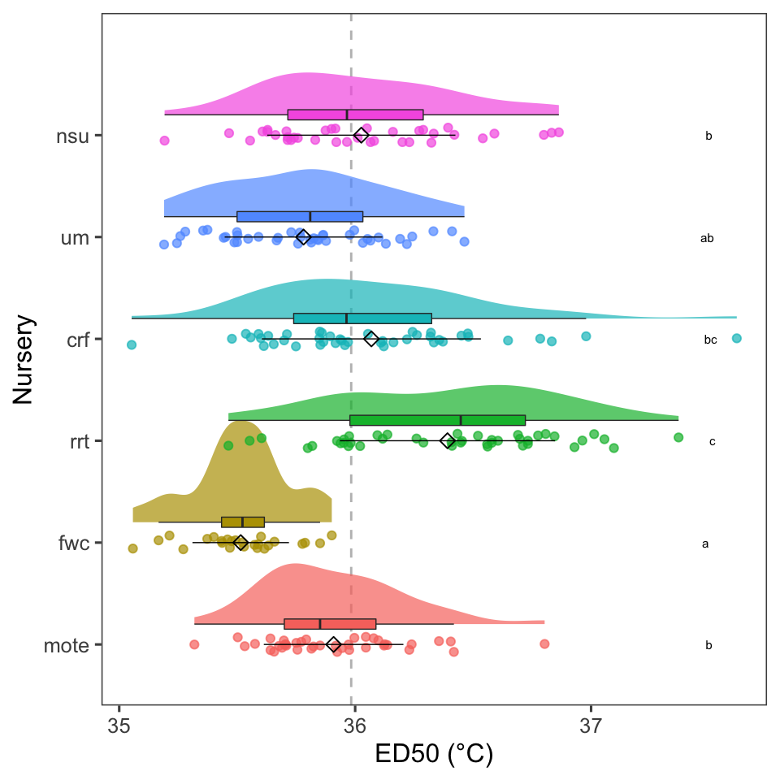

```r
# Use pairwise wilcox to test for differences in ED50 among nurseries
test <- pairwise.wilcox.test(res$estimate_ed50, res$nursery, p.adjust.method = "bonf")
pvals <- tibble(reshape2::melt(test$p.value)) %>% drop_na() %>%
  mutate(Var1 = factor(Var1, levels = levels(fct_reorder(nurs.stats$nursery, nurs.stats$mean)))) %>%
  arrange(Var1)
stats <- setNames(pull(pvals[,3]), paste(pvals$Var1, pvals$Var2, sep = "-")) %>%
  multcompLetters(threshold = 0.01)
lett <- enframe(stats$monospacedLetters, name = "nursery", value = "group")
nurs.stats <- left_join(nurs.stats, lett)


# Raincloud plot
source("https://raw.githubusercontent.com/datavizpyr/data/master/half_flat_violinplot.R")
nurs.fig <- ggplot(res, aes(x = nursery, y = estimate_ed50, fill = nursery, group = nursery)) +
  geom_hline(aes(yintercept = mean(estimate_ed50)), lty = 2, col = "gray") +
  geom_flat_violin(position = position_nudge(x = 0.2, y = 0),
                   adjust = 1, width = 2, alpha = 0.7, lwd = 0) +
  geom_boxplot(position = position_nudge(x = 0.2, y = 0), width = 0.1,
               outlier.shape = NA, alpha = 1, lwd = 0.25) +
  geom_point(aes(color = nursery), alpha = 0.7,
             position = position_jitter(width = 0.075)) +
  geom_point(data = nurs.stats, aes(x = nursery, y = mean), inherit.aes = FALSE,
             position = position_nudge(x = 0, y = 0), size = 2, pch = 5) +
  geom_errorbar(data = nurs.stats, inherit.aes = FALSE, width = 0, lwd = 0.25,
                aes(x = nursery, y = mean, ymin = mean - sd, ymax = mean + sd),
                position = position_nudge(x = 0, y = 0)) +
  geom_text(data = nurs.stats, aes(y = 37.5, label = group), size = 2) +
  coord_flip() +
  scale_size(range = c(0.5, 3)) +
  scale_shape_manual(values = c(21, 22, 23, 24, 25)) +
  theme_few() +
  theme(legend.position = "none") +
  labs(y = "ED50 (°C)", x = "Nursery")
nurs.fig
```

```r
ggsave("output/fig3.png", width = 120, height = 100, units = "mm")
```

There is variation among nurseries in average ED50 values. This could be due to different environmental conditions, and/or different set of genotypes present, and/or confounding experimental effects. However, most of the variation in thermal tolerance is found *within* nurseries rather than between them. This means that each nursery tends to have genets with a wide range of thermal tolerance phenotypes.

# How does thermal tolerance vary for the same genotype grown at different nurseries?

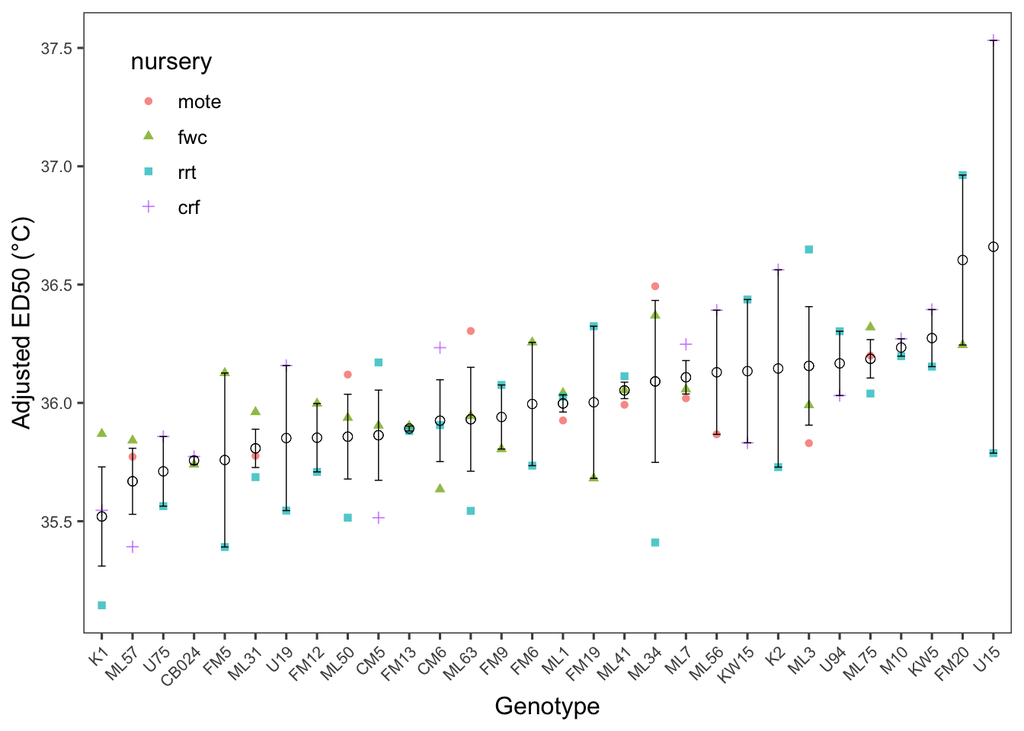

```r
# Get ED50s (adjusted for nursery effect) for genotypes present at multiple nurseries
multi.adj <- res.adj %>%
  # Filter genotypes present at more than one nursery
  group_by(geno) %>%
  filter(n_distinct(nursery) > 1) %>%
  # If genotype run more than once at a nursery, use mean ed50 within nursery
  group_by(geno, nursery) %>%
  summarize(ed50_adj = mean(ed50_adj)) %>%
  ungroup()
# Reorder genotypes based on mean ed50 across nurseries
multi.adj <- multi.adj %>%
  group_by(geno) %>%
  summarize(geno_mean_ed50 = mean(ed50_adj)) %>%
  right_join(multi.adj) %>%
  mutate(geno = fct_reorder(geno, geno_mean_ed50))

# multi.adj %>%
#   count(geno, name = "n_nurs") %>%
#   count(n_nurs, name = "n_geno")

# multi <- res %>%
#   group_by(geno) %>%
#   filter(n_distinct(nursery) > 1) %>%
#   # If genotype run more than once at a nursery, use mean ed50 within nursery
#   group_by(geno, nursery) %>%
#   summarize(estimate_ed50 = mean(estimate_ed50)) %>%
#   ungroup()
#
# # Adjust for nursery differences
# multi.adj <- multi %>%
#   group_by(nursery) %>%
#   summarise(nurs_mean = mean(estimate_ed50)) %>%
#   ungroup() %>%
#   right_join(multi) %>%
#   mutate(.resid = estimate_ed50 - nurs_mean,
#          ed50_adj = mean(estimate_ed50) + .resid)
# multi.adj <- multi.adj %>%
#   # Reorder genotypes based on mean ed50 across nurseries
#   group_by(geno) %>%
#   summarize(geno_mean_ed50 = mean(ed50_adj)) %>%
#   right_join(multi.adj) %>%
#   mutate(geno = fct_reorder(geno, geno_mean_ed50))


# Plot ED50adj by genotype
ggplot(multi.adj, aes(x = geno, y = ed50_adj, color = nursery, shape = nursery, group = geno)) +
  geom_point(size = 1.5, alpha = 0.75) +
  geom_point(aes(y = geno_mean_ed50), pch = 1, color = "black", stroke = 0.25, size = 2)+
  stat_summary(fun.data = mean_se, geom = "errorbar", color = "black", lwd = 0.25, width = 0.25) +
  theme_few() +
  theme(axis.text.x = element_text(angle = 45, hjust = 1),
        axis.text = element_text(size = 8),
        legend.position = c(0.1, 0.8)) +
  labs(x = "Genotype", y = "Adjusted ED50 (°C)")
```

```r
tidy(anova(lm(ed50_adj ~ geno, data = multi.adj))) %>%
  knitr::kable(caption = "ANOVA: Effect of genotype on ED50")
```

ANOVA: Effect of genotype on ED50

| term | df | sumsq | meansq | statistic | p.value |
| --- | --- | --- | --- | --- | --- |
| geno | 29 | 4.071366 | 0.1403919 | 1.022851 | 0.4648661 |
| Residuals | 43 | 5.901990 | 0.1372556 | NA | NA |

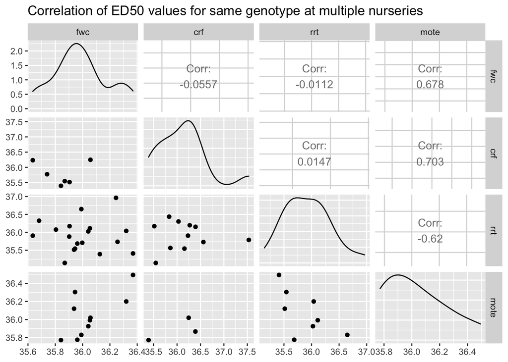

```r
library(GGally)
cors <- multi.adj %>%
  select(nursery, geno, ed50_adj) %>%
  pivot_wider(names_from = nursery, values_from = ed50_adj, values_fn = mean) %>%
  select(-geno)

ggpairs(cors, title = "Correlation of ED50 values for same genotype at multiple nurseries")
```

```r
corfig <- ggpairs(cors)
ggsave(plot = corfig, filename = "output/figS2.png", width = 190, height = 190, units = "mm")

# library(RVenn)
# overlap <- res.adj %>%
#   distinct(nursery, geno) %>%
#   {split(.$geno, .$nursery)} %>%
#   Venn(.) %>%
#   overlap_pairs(.) %>%
#   map(length) %>%
#   unlist()
# overlap
# hist(overlap)
# mean(overlap)
# median(overlap[overlap > 0])

#ggsave("output/fig5.png", width = 90, height = 75, units = "mm")

# # Randomize ed50 values
# multi.adj.r <- multi.adj %>%
#   select(-geno_mean_ed50) %>%
#   mutate(ed50_adj = sample(ed50_adj))
# multi.adj.r %>%
#   # Reorder genotypes based on mean ed50 across nurseries
#   group_by(geno) %>%
#   summarize(geno_mean_ed50 = mean(ed50_adj)) %>%
#   right_join(multi.adj.r) %>%
#   ungroup() %>%
#   mutate(geno = fct_reorder(geno, geno_mean_ed50)) %>%
#   ggplot(aes(x = geno, y = ed50_adj, color = nursery, shape = nursery, group = geno)) +
#   geom_point(size = 1.5, alpha = 0.75) +
#   geom_point(aes(y = geno_mean_ed50), pch = 1, color = "black", stroke = 0.25, size = 2)+
#   stat_summary(fun.data = mean_se, geom = "errorbar", color = "black", lwd = 0.25, width = 0.25) +
#   theme_few() +
#   theme(axis.text.x = element_text(angle = 45, hjust = 1),
#         axis.text = element_text(size = 8),
#         legend.position = c(0.1, 0.8)) +
#   labs(x = "Genotype", y = "Adjusted ED50 (°C)")
#
# # Test for equal variance across genotypes
# car::leveneTest(ed50_adj ~ geno, data = multi.adj.r)    # p = 0.019 => cannot use classic ANOVA
#
# # Test for differences among genotypes with Welch's ANOVA
# (welch <- oneway.test(ed50_adj ~ geno, data = multi.adj.r, var.equal = F))
# ## Significant effect of genotype. Interpretation: ED50 value has a strong genetic component, and thermal tolerance phenotypes for a genet are reproducible even when genet moved to new environment.
#
# # Estimate variance explained by genotype
# omega.squared <- function(WelchF, df, N) df * (WelchF - 1) / (df * (WelchF - 1) + N)
# omega.squared(WelchF = welch$statistic[[1]], df = welch$parameter[[1]], N = nrow(multi.adj))
# ## Genotype explains 49% of variance in ED50 measured across nurseries. Residual variance may be due to genotype by environment interactions (e.g., differential acclimatization of genotypes to different nursery environments), or CBASS run variability & measurement error.
# anova(lm(ed50_adj ~ geno, data = multi.adj.r))
#
#
#
#
# # Use unadjusted data?
# # Get ED50s (adjusted for nursery effect) for genotypes present at multiple nurseries
# multi <- res %>%
#   # Filter genotypes present at more than one nursery
#   group_by(geno) %>%
#   filter(n_distinct(nursery) > 1) %>%
#   # If genotype run more than once at a nursery, use mean ed50 within nursery
#   group_by(geno, nursery) %>%
#   summarize(ed50 = mean(estimate_ed50)) %>%
#   ungroup()
# # Reorder genotypes based on mean ed50 across nurseries
# multi <- multi %>%
#   group_by(geno) %>%
#   summarize(geno_mean_ed50 = mean(ed50)) %>%
#   right_join(multi) %>%
#   mutate(geno = fct_reorder(geno, geno_mean_ed50))
#
# mod <- lm(ed50 ~ nursery + geno, data =  multi)
# anova(mod)
# car::Anova(mod, type = 3, white.adjust = TRUE)
# oneway.test(ed50 ~ geno, data = mutate(multi, ed50 = sample(ed50)), var.equal = F)
#
# # These tests are really unstable with randomized data, don't think results are reliable. Sample sizes for each geno are so small.
```

Genotype is not a significant predictor of ED50 among coral genotypes tested at multiple nurseries. This could indicate that: 1) ED50 is plastic and genotype by environment interactions result in genotypes having different ED50 values at different nurseries, and/or 2) small sample sizes for each genotype limit statistical power to detect differences among genotypes. The 30 genotypes in this subset were present at only two (n=17) or three nurseries (n=13), so the low replication for each genotype is definitely a limitation. This study was not really designed to be able to answer this question, but the genotype swap experiment should hopefully be able to!

# Is thermal tolerance related to source colony latitude and longitude?

```r
mod <- lm(ed50_adj ~ source_lat + source_lon, data = res.adj)
anova(mod) %>%
  tidy() %>%
  knitr::kable()
```

| term | df | sumsq | meansq | statistic | p.value |
| --- | --- | --- | --- | --- | --- |
| source_lat | 1 | 0.0087050 | 0.0087050 | 0.0622938 | 0.8031415 |
| source_lon | 1 | 0.0459479 | 0.0459479 | 0.3288067 | 0.5669536 |
| Residuals | 218 | 30.4636341 | 0.1397414 | NA | NA |

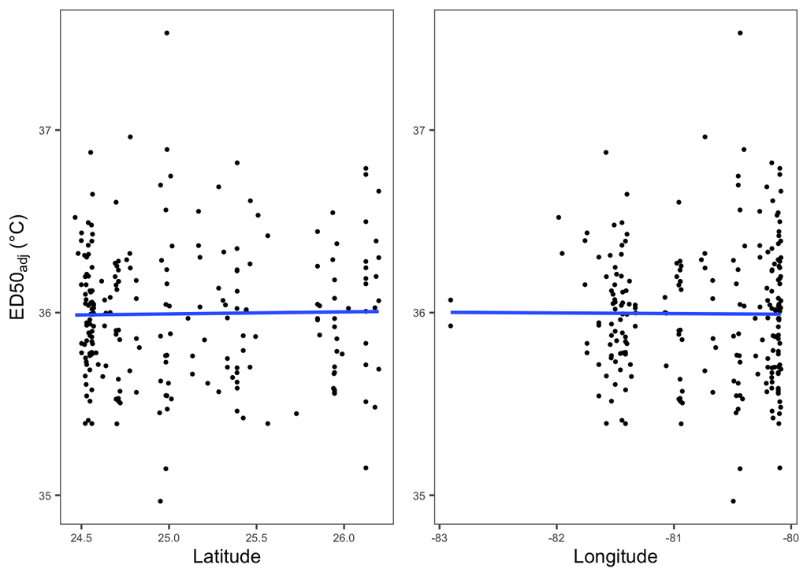

```r
lat.plot <- ggplot(res.adj, aes(x = source_lat, y = ed50_adj)) +
  geom_point(size = 0.75) +
  geom_smooth(method = "lm", se = FALSE) +
  theme_few() +
  theme(axis.text = element_text(size = 7)) +
  labs(x = "Latitude", y = expression(paste(ED50[adj], " (°C)")))

lon.plot <- ggplot(res.adj, aes(x = source_lon, y = ed50_adj)) +
  geom_point(size = 0.75) +
  geom_smooth(method = "lm", se = FALSE) +
  theme_few() +
  theme(axis.text = element_text(size = 7)) +
  labs(x = "Longitude", y = NULL)

cowplot::plot_grid(lat.plot, lon.plot, ncol = 2)
```

# Is thermal tolerance related to source colony temperature regime?

To test this hypothesis, we calculate maximum monthly mean (MMM) temperatures corresponding to each source colony location, using satellite SST products with both 9km and 5km resolution.

```r
# Import 9km SST data
sst9 <- tibble(
  filename = list.files("data/sst_9km", full.names = TRUE),
  data = map(filename, read_csv, col_names = c("yyyymm", "temp")),
  coords = map(filename, ~ str_split_fixed(basename(.), "_", 4)),
  lat = map_dbl(coords, ~ as.numeric(nth(., 3))),
  lon = map_dbl(coords, ~ parse_number(nth(., 4)))
) %>%
  select(lat, lon, data)

sst9 <- sst9 %>%
  mutate(data = map(data, ~ mutate(., year = str_sub(yyyymm, 1, 4), month = str_sub(yyyymm, 5, 6)))) %>%
  mutate(monthly_means = map(data, ~ group_by(., month) %>% summarize(mean = mean(temp))),
         mmm_9km = map_dbl(monthly_means, ~ max(.$mean)),
         minmm = map_dbl(monthly_means, ~ min(.$mean)),
         totvar = map_dbl(data, ~ var(.$temp)),
         sumvar = map_dbl(data, ~ filter(.,  month %in% c("07", "08", "09")) %>%
                            summarize(var = var(temp)) %>% pull(var)))

# Join with results and sample metadata
dft <- sst9 %>%
  distinct(source_lat = lat, source_lon = lon, mmm_9km, minmm, totvar, sumvar) %>%
  right_join(res.adj) %>%
  mutate(mmm_5km = as.numeric(mmm_5km))

# Test effect of MMM from 9km data
mod9km <- lm(ed50_adj ~ mmm_9km, data = dft)
anova(mod9km) %>%
  tidy() %>%
  knitr::kable()
```

| term | df | sumsq | meansq | statistic | p.value |
| --- | --- | --- | --- | --- | --- |
| mmm_9km | 1 | 0.2432514 | 0.2432514 | 1.971079 | 0.1626641 |
| Residuals | 133 | 16.4135648 | 0.1234103 | NA | NA |

```r
# Test effect of MMM from 5km data
mod5km <- lm(ed50_adj ~ mmm_5km, data = dft)
anova(mod5km) %>%
  tidy() %>%
  knitr::kable()
```

| term | df | sumsq | meansq | statistic | p.value |
| --- | --- | --- | --- | --- | --- |
| mmm_5km | 1 | 0.0000005 | 0.0000005 | 3.7e-06 | 0.9984598 |
| Residuals | 219 | 30.5182865 | 0.1393529 | NA | NA |

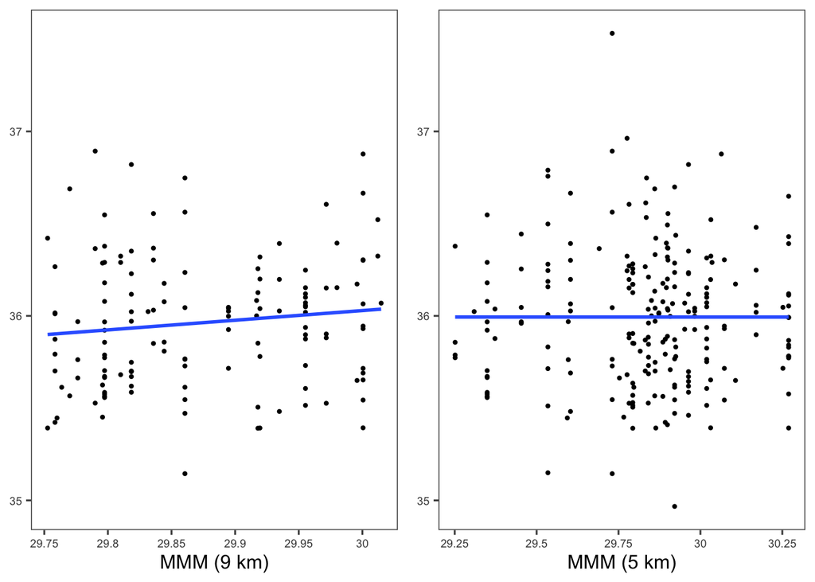

```r
# Plots
mmm9.plot <- ggplot(dft, aes(x = mmm_9km, y = ed50_adj)) +
  geom_point(size = 0.75) +
  geom_smooth(method = "lm", se = FALSE) +
  theme_few() +
  theme(axis.text = element_text(size = 7)) +
  scale_x_continuous(labels = function(x) str_trim(x)) +
  labs(x = "MMM (9 km)", y = NULL)

mmm5.plot <- ggplot(dft, aes(x = mmm_5km, y = ed50_adj)) +
  geom_point(size = 0.75) +
  geom_smooth(method = "lm", se = FALSE) +
  theme_few() +
  theme(axis.text = element_text(size = 7)) +
  scale_x_continuous(labels = function(x) str_trim(x)) +
  labs(x = "MMM (5 km)", y = NULL)

cowplot::plot_grid(mmm9.plot, mmm5.plot, ncol = 2)
```

```r
fig4 <- cowplot::plot_grid(lat.plot, lon.plot, mmm9.plot, mmm5.plot, nrow = 1,
                   rel_widths = c(1.07,1,1,1), labels = "AUTO")
ggsave(plot = fig4, filename = "output/fig4.png", width = 190, height = 50, units = "mm")
```

```r
mod <- lm(ed50_adj ~ source_lat * source_lon * mmm_9km * mmm_5km, data = dft)
anova(mod) %>%
  tidy() %>%
  knitr::kable()
```

| term | df | sumsq | meansq | statistic | p.value |
| --- | --- | --- | --- | --- | --- |
| source_lat | 1 | 0.0188106 | 0.0188106 | 0.1484424 | 0.7006938 |
| source_lon | 1 | 0.0938567 | 0.0938567 | 0.7406616 | 0.3911235 |
| mmm_9km | 1 | 0.1542045 | 0.1542045 | 1.2168907 | 0.2721253 |
| mmm_5km | 1 | 0.0100576 | 0.0100576 | 0.0793685 | 0.7786284 |
| source_lat:source_lon | 1 | 0.0111930 | 0.0111930 | 0.0883282 | 0.7668147 |
| source_lat:mmm_9km | 1 | 0.2159915 | 0.2159915 | 1.7044770 | 0.1941402 |
| source_lon:mmm_9km | 1 | 0.2041681 | 0.2041681 | 1.6111738 | 0.2067234 |
| source_lat:mmm_5km | 1 | 0.0031903 | 0.0031903 | 0.0251757 | 0.8741903 |
| source_lon:mmm_5km | 1 | 0.2605270 | 0.2605270 | 2.0559251 | 0.1541524 |
| mmm_9km:mmm_5km | 1 | 0.0069410 | 0.0069410 | 0.0547743 | 0.8153438 |
| source_lat:mmm_9km:mmm_5km | 1 | 0.0913057 | 0.0913057 | 0.7205304 | 0.3976190 |
| Residuals | 123 | 15.5865703 | 0.1267201 | NA | NA |

There are no relationships between ED50 and source colony latitude, longitude, or MMM temperature. This is a pretty cool finding because it suggests that thermally tolerant colonies are not restricted to specific locations, but can be found throughout the Florida reef tract.